# HW9

## Домашнее задание 9.Практическое занятие по молекулярной динамике.

### Моделирование плавления алфа-спирального пептида в формамиде

### Горохов Никита

Сначала загрузим необходимые файлы

```python
!wget http://kodomo.cmm.msu.ru/~golovin/pep_melt/2xl1.pdb
!wget http://kodomo.cmm.msu.ru/~golovin/pep_melt/fam_em.gro
!wget http://kodomo.cmm.msu.ru/~golovin/pep_melt/fam.itp
!wget http://kodomo.cmm.msu.ru/~golovin/pep_melt/em.mdp
!wget http://kodomo.cmm.msu.ru/~golovin/pep_melt/pr.mdp
!wget http://kodomo.cmm.msu.ru/~golovin/pep_melt/md.mdp
```

[output not shown]

[output cut: 10 more lines]

[output not shown]

Построим файл топологии системы в силовом поле amber99sb и файл с координатами в формате *Gromacs*.  
Будем использовать с флагом **-ignh**, для игнорирования атомов водорода в pdb файле.

```python
!pdb2gmx -f 2xl1.pdb -o pep -p pep -ff amber99sb -water tip3p -ignh
```

[output not shown]

[output cut: 92 more lines]

```
Before cleaning: 638 dihedrals
Keeping all generated dihedrals
Making cmap torsions...There are  638 dihedrals,   56 impropers,  436 angles
           622 pairs,      246 bonds and     0 virtual sites
Total mass 1787.948 a.m.u.
Total charge -1.000 e
Writing topology

Writing coordinate file...
		--------- PLEASE NOTE ------------
You have successfully generated a topology from: 2xl1.pdb.
The Amber99sb force field and the tip3p water model are used.
		--------- ETON ESAELP ------------

gcq#210: "Is That a Real Poncho ?" (F. Zappa)
```

Сделаем небольшой отступ в ячейке от пептида.

```python
!editconf -f pep.gro -o pep_ec -d 1.5
```

[output not shown]

[output cut: 39 more lines]

```
    center      :  0.381  0.143 -0.145 (nm)
    box vectors :  0.100  0.100  0.100 (nm)
    box angles  :  90.00  90.00  90.00 (degrees)
    box volume  :   0.00               (nm^3)
    shift       :  2.152  2.192  2.256 (nm)
new center      :  2.532  2.335  2.111 (nm)
new box vectors :  5.065  4.670  4.221 (nm)
new box angles  :  90.00  90.00  90.00 (degrees)
new box volume  :  99.84               (nm^3)

WARNING: No boxtype specified - distance condition applied in each dimension.
If the molecule rotates the actual distance will be smaller. You might want
to use a cubic box instead, or why not try a dodecahedron today?

gcq#177: "Pump Up the Volume Along With the Tempo" (Jazzy Jeff)
```

Проведём оптимизацию геометрии системы, что бы удалить "плохие" контакты в молекуле.

```python
!grompp -f em -c pep_ec -p pep -o pep_em -maxwarn 1
!mdrun -deffnm pep_em -v
```

[output not shown]

[output cut: 254 more lines]

```
Stepsize too small, or no change in energy.
Converged to machine precision,
but not to the requested precision Fmax < 1

Double precision normally gives you higher accuracy.

writing lowest energy coordinates.

Low-Memory BFGS Minimizer converged to machine precision in 96 steps,
but did not reach the requested Fmax < 1.
Potential Energy  =  9.5273560e+02
Maximum force     =  3.2095328e+02 on atom 30
Norm of force     =  8.4225098e+01

gcq#310: "Shoot them in the back now" (The Ramones)
```

Отметем изменение максимальной силы в ходе оптимизации геометрии:

- начальное значение максимальной силы: Fmax=2.295e+03 (atom 150)
- конечное значение максимальной силы: Fmax=3.210e+02 (atom 30)

Теперь добавим в ячейку молекулы формамида.

```python
!genbox -cp pep_em -p pep -cs fam_em.gro -o pep_s
```

[output not shown]

[output cut: 42 more lines]

```
Added 902 molecules
Generated solvent containing 5412 atoms in 902 residues
Writing generated configuration to pep_s.gro
ARGININE ATTENUATOR PEPTIDE

Output configuration contains 5655 atoms in 917 residues
Volume                 :     99.8416 (nm^3)
Density                :     755.207 (g/l)
Number of SOL molecules:      0

Processing topology

Back Off! I just backed up pep.top to ./#pep.top.1#

gcq#111: "Motherhood Means Mental Freeze" (The Breeders)
```

Итого добавилось **902** молекулы формамида

Теперь надо изменить в текстовом редакторе файл тополгии pep.top.  
Для этого:

- после строчки **; Include forcefield parameters** добавим строчку **#include "fam.itp"**
- Добавим количество молекул формамида в запись [ molecules ]  
  [ molecules ]  
  ; Compound #mols  
  Protein_chain_A 1  
  FAM 902

```python
!cat pep.top
```

```
;
;	File 'pep.top' was generated
;	By user: nsgorokhov (1092)
;	On host: shadbox
;	At date: Sun Dec 22 17:01:13 2019
;
;	This is a standalone topology file
;
;	It was generated using program:
;	pdb2gmx - VERSION 4.5.5
;
;	Command line was:
;	pdb2gmx -f 2xl1.pdb -o pep -p pep -ff amber99sb -water tip3p -ignh
;
;	Force field was read from the standard Gromacs share directory.
```

[output cut: 2310 more lines]

Нейтрализуем заряд системы. Это делаем в два шага: строим tpr и запускаем genion

```python
!grompp -f em -p pep -c pep_s -o pep_s -maxwarn 5
```

[output not shown]

[output cut: 43 more lines]

```
Analysing residues not classified as Protein/DNA/RNA/Water and splitting into groups...
Number of degrees of freedom in T-Coupling group rest is 16962.00

NOTE 2 [file em.mdp]:
  You are using a plain Coulomb cut-off, which might produce artifacts.
  You might want to consider using PME electrostatics.


This run will generate roughly 803 Mb of data

There were 2 notes

There was 1 warning

gcq#148: "Everybody's Good Enough For Some Change" (LIVE)
```

```python
!genion -s pep_s -o pep_si -p pep -np 1
```

[output not shown]

[output cut: 27 more lines]

```
Group     0 (         System) has  5655 elements
Group     1 (        Protein) has   243 elements
Group     2 (      Protein-H) has   127 elements
Group     3 (        C-alpha) has    15 elements
Group     4 (       Backbone) has    45 elements
Group     5 (      MainChain) has    61 elements
Group     6 (   MainChain+Cb) has    76 elements
Group     7 (    MainChain+H) has    78 elements
Group     8 (      SideChain) has   165 elements
Group     9 (    SideChain-H) has    66 elements
Group    10 (    Prot-Masses) has   243 elements
Group    11 (    non-Protein) has  5412 elements
Group    12 (          Other) has  5412 elements
Group    13 (            FAM) has  5412 elements
Select a group: ^C
```

Проведём "утряску" воды:

```python
!grompp -f pr -c pep_si -p pep -o pep_pr -maxwarn 2
```

[output not shown]

[output cut: 39 more lines]

```
There are:     1        Ion residues
Analysing Protein...
Analysing residues not classified as Protein/DNA/RNA/Water and splitting into groups...
Analysing residues not classified as Protein/DNA/RNA/Water and splitting into groups...
Number of degrees of freedom in T-Coupling group Protein is 482.88
Number of degrees of freedom in T-Coupling group FAM is 11710.12
Number of degrees of freedom in T-Coupling group NA is 3.00
Calculating fourier grid dimensions for X Y Z
Using a fourier grid of 45x40x36, spacing 0.113 0.117 0.117
Estimate for the relative computational load of the PME mesh part: 0.17
This run will generate roughly 1 Mb of data

There was 1 note

gcq#175: "That Was Really Cool" (Butthead)
```

```python
!mdrun -deffnm pep_pr -v
```

[output not shown]

[output cut: 65 more lines]

```
Writing final coordinates.
step 1000, remaining runtime:     0 s
 Average load imbalance: 33.5 %
 Part of the total run time spent waiting due to load imbalance: 1.2 %


	Parallel run - timing based on wallclock.

               NODE (s)   Real (s)      (%)
       Time:     67.660     67.660    100.0
                       1:07
               (Mnbf/s)   (MFlops)   (ns/day)  (hour/ns)
Performance:      9.772    987.408      0.256     93.878

gcq#335: "Jede der Scherben spiegelt das Licht" (Wir sind Helden)
```

Переформатируйте pep_pr.gro и pep_si.gro в pdb формат.

```python
!editconf -f pep_pr.gro -o pep_pr.pdb
!editconf -f pep_si.gro -o pep_si.pdb
```

[output not shown]

[output cut: 113 more lines]

[output not shown]

Сравнив визуализацию в *PyMol* Молекулы на первой картинке до утряски. Видно, что все упорядочено. Молекулы на второй картинке после утряски. Наблюдается хаотинчное положение молекул.

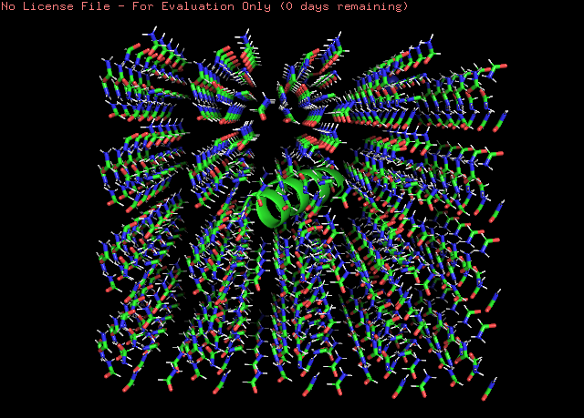

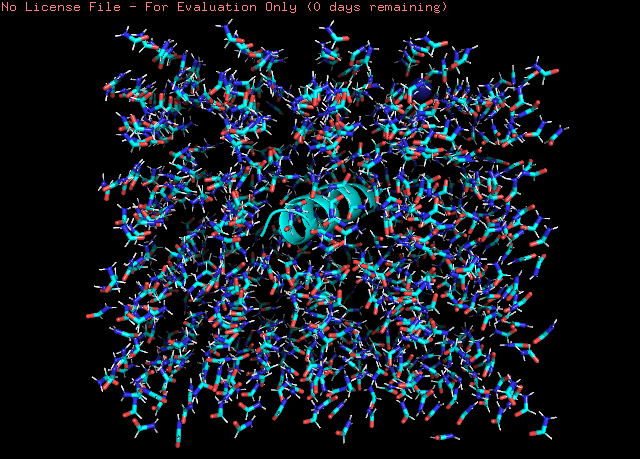

```python
from IPython.display import Image, display

display(Image(filename="pep_si.png"),
       Image(filename="pep_pr.png"))
```

```python
!grompp -f md -c pep_pr -p pep -o pep_md -maxwarn 1
```

[output not shown]

[output cut: 40 more lines]

```
There are:   901      Other residues
There are:     1        Ion residues
Analysing Protein...
Analysing residues not classified as Protein/DNA/RNA/Water and splitting into groups...
Analysing residues not classified as Protein/DNA/RNA/Water and splitting into groups...
Number of degrees of freedom in T-Coupling group Protein is 482.88
Number of degrees of freedom in T-Coupling group non-Protein is 11713.12
Calculating fourier grid dimensions for X Y Z
Using a fourier grid of 45x40x36, spacing 0.113 0.117 0.117
Estimate for the relative computational load of the PME mesh part: 0.17
This run will generate roughly 105 Mb of data

There was 1 note

gcq#80: "Everybody Lie Down On the Floor and Keep Calm" (KLF)
```

Теперь перейдем к моделированию. Я локально установил последнюю версию *gromacs* и запустил считаться у себя. Время выполнения около 2ух часов.

### Анализ результатов

Версия gromacs - *2020-rc1*. Поэтому некоторые команды и параметры отличаются, от тех, что описаны в инструкции.

Любой анализ начинают с визуального анализа движений молекул. При вопросе о выводе групп выберем **Protein**.

```
gmx trjconv -f pep_md.xtc -s pep_md.tpr -o pep_pbc_1.pdb -skip 20 \
-pbc mol
gmx trjconv -f pep_md.xtc -s pep_md.tpr -o pep_fit_1.pdb -skip 20 \
-fit rot+trans
```

```python
from IPython.display import HTML, display

display(HTML("""
    <h2>
        pbc
    </h2>
    <video alt="test" controls>
        <source src="result/pep_pbc_1.mp4" type="video/mp4">
    </video>
    """))
display(HTML("""
    <h2>
        fit
    </h2>
    <video alt="test" controls>
        <source src="result/pep_fit_1.mp4" type="video/mp4">
    </video>
    """))
```

pbc

[video not shown]

fit

[video not shown]

Для анализа удобна вторая анимация, так как на ней молекула находится в центре, и не так хаотично двигется. Видно, что конец спирали периодично расплетается и в итоге он расплавляется. Другой конец тоже расплавился (не полностью).

Определите средне-квадратичное отколнение в ходе моделирования. Так как у нас происходит конформационный переход сначала расчитаем отклонение в ходе все симуляции относительно стартовой структуры.

```
gmx rms -f pep_md.xtc -s pep_md.tpr -o rms_1
```

И относительно каждой предидущей структуры на растоянии 400 кадров. Если ближе к концу закончился конформационный переход, то отколнение должно уменьшаться.

```
gmx rms -f pep_md.xtc -s pep_md.tpr -o rms_2 -prev 400
```

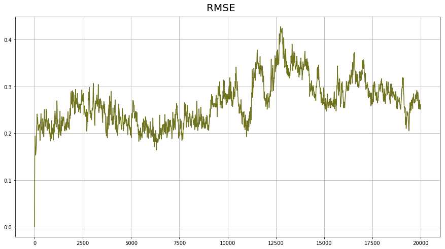

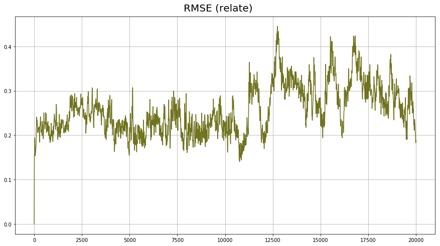

```python
import matplotlib.pyplot as plt
import numpy as np

fig = plt.figure(figsize=(15, 8))
data = np.loadtxt('result/rms_1.xvg')
plt.plot(data[:,0], data[:, 1], color='#70731F')
plt.figtext(.5, .9, "RMSE", fontsize=20, ha='center')
plt.grid()
plt.show()

fig = plt.figure(figsize=(15, 8))
data = np.loadtxt('result/rms_2.xvg')
plt.plot(data[:,0], data[:, 1], color='#70731F')
plt.figtext(.5, .9, "RMSE (relate)", fontsize=20, ha='center')
plt.grid()
plt.show()
```

Определите изменение гидрофобной и гидрофильной поверхности в ходе конформационного перехода. Для этого воспользуемся [документацией](http://manual.gromacs.org/documentation/2016.3/user-guide/cmdline.html#g-sas). g_sas -> sasa и дополнительно нужно изменить параметры

```
gmx sasa -surface 'group "Protein"' -output '"Hydrophobic" group "Protein" and   charge {-0.2 to 0.2}; "Hydrophilic" group "Protein" and not charge {-0.2 to     0.2}; "Total" group "Protein"' -f pep_md.xtc -s pep_md.tpr -o sas_pep.xvg
```

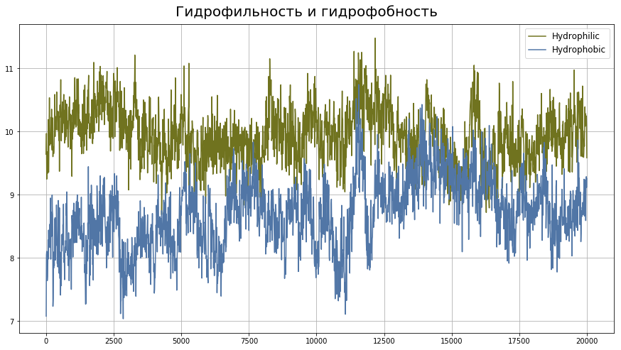

```python
fig = plt.figure(figsize=(15, 8))
data = np.loadtxt('result/sas_pep.xvg')
plt.plot(data[:,0], data[:, 2], color='#70731F', label="Hydrophilic")
plt.plot(data[:,0], data[:, 3], color='#5176A6', label="Hydrophobic")
plt.figtext(.5, .9, "Гидрофильность и гидрофобность".decode("utf-8"), fontsize=20, ha='center')
plt.legend(loc=1, prop={'size': 12})
plt.grid()
plt.show()
```

Традиционным анализом является расчёт колчества образуемых водородных связей. Если мы будем исследовать связи между пептидом и пептидом, то это будут водородные связи в пептиде и не менее интересно будет изучить количество вдородных связей пептид-формамид.

```
gmx hbond  -f pep_md.xtc -s pep_md.tpr -num hbond_pep
gmx hbond  -f pep_md.xtc -s pep_md.tpr -num hbond_pep_sl
```

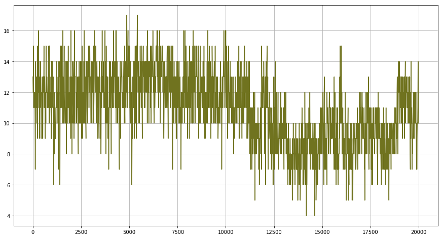

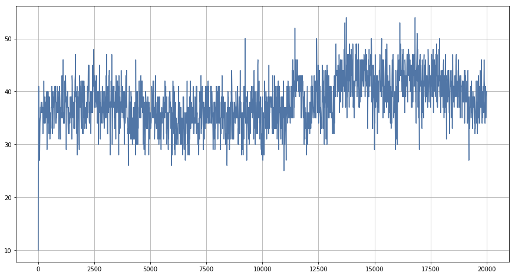

```python
fig = plt.figure(figsize=(15, 8))
data = np.loadtxt('result/hbond_pep.xvg')
plt.plot(data[:,0], data[:, 1], color='#70731F')
plt.grid()
plt.show()

fig = plt.figure(figsize=(15, 8))
data = np.loadtxt('result/hbond_pep_s1.xvg')
plt.plot(data[:,0], data[:, 1], color='#5176A6')
plt.grid()
plt.show()
```

Если у нас происходит разрушение вторичной структуры, то надо построить зависимость вторичной структуры от времени:

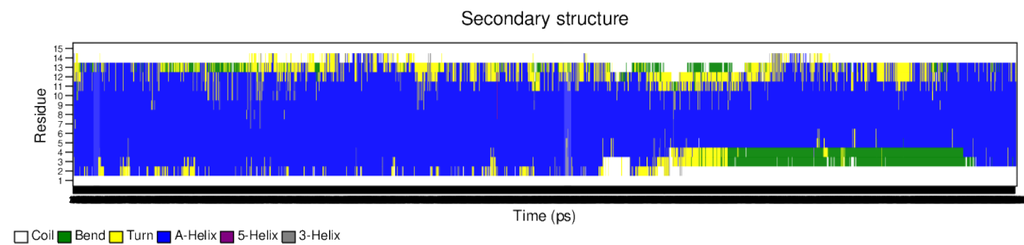

```python
from IPython.display import Image
Image(filename="result/ss.png")
```

Можно сделать вывод, что C и N концы сильно меняются, в то время как центральная составляющая сохраняет свою форму